# Unsupervised Methods

CMSC320

April 19, 2016

### Introduction

So far we have seen “Supervised Methods” where interest is in analyzing a *response* (or outcome) based on various *predictors*. In many cases, especially for Exploratory Data Analysis, we want methods to extract patterns on variables without analyzing a specific *response*. Methods for the latter case are called “Unsupervised Methods”. Examples are *Principal Component Analysis* and *Clustering*.

### Motivating Example

We will use an application in genetics as a motivating example for dimensionality reduction methods.Recent technological advances have allowed identification of locations in human genome (DNA) that vary frequently across human populations (Single Nucleotide Polymorphisms, or SNPs). This permits biomedical researchers to identify changes in DNA that are associated with specific traits, e.g., susceptibility to disease, or protection from disease, which could greatly improve effectiveness and quality of care for certain diseases.

For our example, we will look at a dataset of 4,929 SNPs for 1,093 individuals from populations across the globe. This data is available in the class docker image at `/home/ids_materials/geno_data.rda`.

```r
library(dplyr)
load("geno_data.rda")
print(dim(filtered_geno_data))
```

```
## [1] 1093 4929
```

```r
table(filtered_geno_data$super_population)
```

```
##
## AFR AMR EAS EUR OPT
## 246 181 286 379   1
```

The encoding of the origin of each subject in the sample is given by *AFR: Africa, AMR: America, EAS: East Asia, EUR: Europe, OPT: A mystery*

Let’s take a look at a few of the variables included in this dataset:

```r
filtered_geno_data %>%
  select(1:6) %>%
  head(10) %>%
  knitr::kable()
```

| sample_name | population | super_population | rs307377 | rs7366653 | rs41307846 |
| --- | --- | --- | --- | --- | --- |
| perfect | OPT | OPT | 0 | 0 | 0 |
| HG00096 | GBR | EUR | 2 | 0 | 1 |
| HG00097 | GBR | EUR | 2 | 0 | 0 |
| HG00099 | GBR | EUR | 2 | 0 | 0 |
| HG00100 | GBR | EUR | 2 | 0 | 0 |
| HG00101 | GBR | EUR | 2 | 0 | 0 |
| HG00102 | GBR | EUR | 2 | 0 | 0 |
| HG00103 | GBR | EUR | 2 | 0 | 0 |
| HG00104 | GBR | EUR | 2 | 0 | 1 |
| HG00106 | GBR | EUR | 2 | 0 | 0 |

Each of the `rsXXXX` columns corresponds to a SNP (location in the human genome that varies across populations). These are fairly well annotated, e.g, http://snpedia.com/index.php/rs1799971. For this specific SNP, the vast majority (about 80%) of people in the world inherited an `A` from both mother and father. We say they have the `A/A` allele. Other people have a different allele, `A/G` or `G/G`, meaning they inherited a mutation (`G` instead of `A`) from either mother or father (in the first case) or both (in the second case). These two rare alleles have been associated with increased susceptibility to alcoholism.

Let’s see what the subjects in the dataset look like with respect to this SNP:

```r
table(filtered_geno_data$rs1799971)
```

```
##
##   0   1   2
## 733 305  55
```

In this dataset 733 individuals have the `A/A` allele (coded as `0`), 305 have the `A/G` allele (coded as `1`) and 55 have the `G/G` allele (coded as `2`). In this dataset all SNPs are coded the same way:

- `0`: they have the most frequent allele
- `1`: they inherited one copy of the mutation
- `2`: they inherited two copies of the mutation

In exploratory data analysis we would like to visualize this data for 4k variables. We could make scatter plots for every pair of variables but that is obviously not feasible. This is where unsupervised methods for dimensionality reduction are helpful.

### Principal Component Analysis

Principal Component Analysis (PCA) is a dimensionality reduction method. The goal is to *embed data in high dimensional space (e.g., observations with a large number of variables), onto a small number of dimensions*. Note that its most frequent use is in EDA and visualization, but it can also be helpful in regression (linear or logistic) where we can transform input variables into a smaller number of predictors for modeling. The PCA problem is then:

Given: - Data set $\{\mathbf{x}_1, \mathbf{x}_2, \ldots, \mathbf{x}_n\}$, where $\mathbf{x}_i$ is the vector of $p$ variable values for the $i$-th observation.

Return: - Matrix $\left[ \phi_1, \phi_2, \ldots, \phi_p \right]$ of *linear transformations* that retain *maximal variance*.

You can think of the first vector $\phi_1$ as a linear transformation that embeds observations into 1 dimension:

$$Z_1 = \phi_{11}X_1 + \phi_{21} X_2 + \cdots + \phi_{p1} X_p$$

where $\phi_1$ is selected so that the resulting dataset $\{ z_1, \ldots, z_n\}$ has *maximum variance*. In order for this to make sense mathematically data has to be centered (we saw this in our transformations unit), i.e., each $X_j$ has mean equal to zero and transformation vector $\phi_1$ has to be normalized, i.e., $\sum_{j=1}^p \phi_{j1}^2=1$. We can find $\phi_1$ by (surprise!) solving an optimization problem:

$$\max_{\phi{11},\phi_{21},\ldots,\phi_{p1}} \frac{1}{n} \sum_{i=1}^n \left( \sum_{j=1}^p \phi_{j1} x_{ij} \right)^2 \\
\mathrm{s.t.} \sum_{j=1}^p \phi_{j1}^2 = 1$$

Conceptually this optimization problem says *maximize variance* but *subject to normalization constraint*. The second transformation $\phi_2$ is obtained next solving a similar problem with the added constraint that $\phi_2$ **is orthogonal** to $\phi_1$. Taken together $\left[ \phi_1, \phi_2 \right]$ define a pair of linear transformations of the data into 2 dimensional space.

$$Z_{n\times 2} = X_{n \times p} \left[ \phi_1, \phi_2 \right]_{p \times 2}$$

### Motivating example continued

Let’s apply PCA to our genotype data.

```r
library(dplyr)

load("geno_data.rda")

# do principal component analysis
# genotypes
pr_out <- filtered_geno_data %>%
  select(contains("rs")) %>%
  prcomp(scale=TRUE)

# get the embedded samples and add additional sample information
embedded_samples <- pr_out$x[,1:3] %>%
  as.data.frame() %>%
  bind_cols(select(filtered_geno_data, sample_name, population, super_population))

embedded_samples %>% head() %>% knitr::kable()
```

| PC1 | PC2 | PC3 | sample_name | population | super_population |
| --- | --- | --- | --- | --- | --- |
| -2.220857 | 13.81763 | -193.8613921 | perfect | OPT | OPT |
| -6.034754 | 15.94039 | -0.5350849 | HG00096 | GBR | EUR |
| -6.307303 | 14.79816 | -1.0284508 | HG00097 | GBR | EUR |
| -7.099037 | 15.81301 | -4.3762353 | HG00099 | GBR | EUR |
| -6.004052 | 17.28915 | -0.3868090 | HG00100 | GBR | EUR |
| -7.545034 | 15.61529 | 1.1672255 | HG00101 | GBR | EUR |

Each of the columns of the $Z$ matrix are called *Principal Components*. The units of the PCs are *meaningless*. In particular, comparing numbers *across* PCs doesn’t make mathematical sense. In this case we also used a scaling transformation on the variables $X_j$ to have unit variance (argument `scale` to the `prcomp` function). I would not have done that with this dataset, but we’ll see why I did it shortly. In general, if variables $X_j$ are measured in different units (e.g, miles vs. liters vs. dollars), variables should be scaled to have unit variance. Conversely, if they are all measured in the same units (as in this example), you should not scale them.

Let’s make a scatter plot of the embedded dataset resulting from PCA:

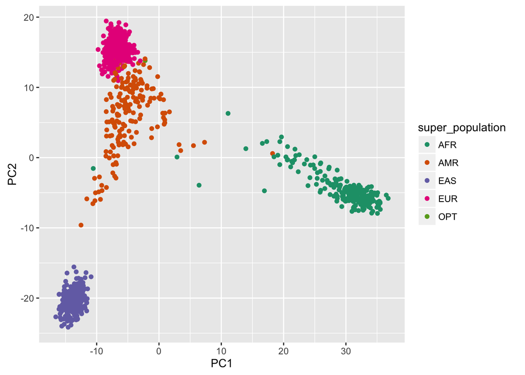

```r
library(ggplot2)

embedded_samples %>%
  ggplot(aes(x=PC1, y=PC2, color=super_population)) +
    geom_point() +
     scale_color_brewer(palette="Dark2")
```

We see that the first PC roughly corresponds to African population and the second component rouhgly corresponds to Eastern Asian population. The American population, however, is not as well defined as the other populations. Remember that we did not used these labels to embed the data into two dimensions, we are using them afterwards to aid interpretation.

We can also look at the $\phi$ vectors that define the transformations (aka *loadings*) to see how much weight each of the original variables in the dataset is assigned to each PC. This analysis only makes sense if all variables are on the same scale (thus, the reason for a scaling transformation). For example, we can find the SNPs with highest weight for the first principal component:

```r
o <- order(-abs(pr_out$rotation[,1]))
snp_indices <- o[1:10]
snp_ids <- rownames(pr_out$rotation)[snp_indices]

snp_tab <- data.frame(SNP=sprintf("[%s](http://snpedia.com/index.php/%s)", snp_ids, snp_ids),
                      PC1=round(pr_out$rotation[snp_indices,1],4),
                      PC2=round(pr_out$rotation[snp_indices,2],4)) %>%
  magrittr::set_rownames(NULL)
knitr::kable(snp_tab)
```

| SNP | PC1 | PC2 |
| --- | --- | --- |
| rs2740574 | -0.0510 | 0.0072 |
| rs10743430 | -0.0495 | 0.0062 |
| rs2643103 | -0.0484 | 0.0179 |
| rs2032487 | -0.0481 | 0.0050 |
| rs4821480 | -0.0479 | 0.0049 |
| rs4821481 | -0.0479 | 0.0049 |
| rs9891361 | -0.0475 | 0.0102 |
| rs710079 | 0.0467 | -0.0160 |
| rs3136687 | 0.0466 | -0.0114 |
| rs5750248 | -0.0460 | 0.0043 |

A type of plot commonly used in PCA analysis is the `biplot` which combines visualization of embedded data and loadings. **I don’t like it!**

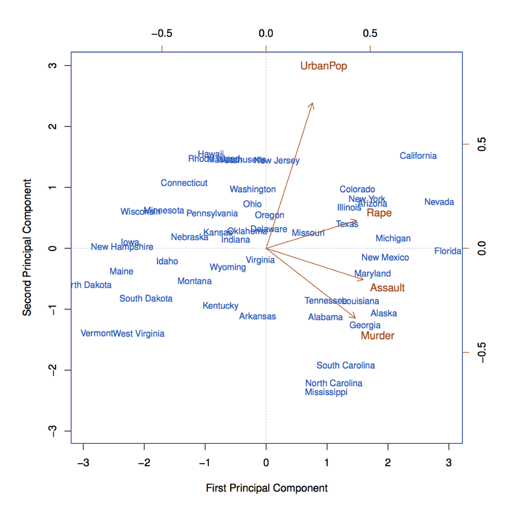

### Other PCA practicalities

A natural question that arises is: How many PCs should we consider in post-hoc analysis? One result of PCA is a measure of the variance corresponding to each PC relative to the total variance of the dataset. From that we can calculate the *percentage of variance explained* for the $m$-th PC:

$$PVE_m=\frac{\sum_{i=1}^n z_{im}^2}{\sum_{j=1}^p \sum_{i=1}^n x_{ij}^2}$$

We can use this measure to choose number of PCs in an ad-hoc manner In our case, using more than 3 PCs does not add information.

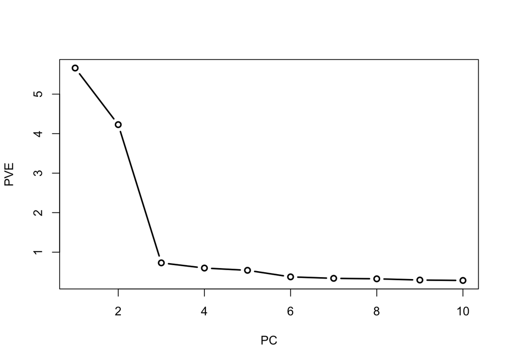

```r
pr_vars <- pr_out$sdev^2
pve <- pr_vars / sum(pr_vars)

plot(pve[1:10]*100, type="b", xlab="PC", ylab="PVE", lwd=2)
```

A useful *rule of thumb*: - If no apparent patterns in first couple of PCs, stop! - Otherwise, look at other PCs using PVE as guide.

Still, this is very much ad-hoc, and no commonly agreed upon method for choosing number of PCs used in practice.

### Our motivating example explained

A final caveat: PCA is **notoriously easy** to over-interpret… Let’s reveal the source of our motivating data. This came from a [blog post](https://liorpachter.wordpress.com/2014/12/02/the-perfect-human-is-puerto-rican/) by [Lior Pachter](https://math.berkeley.edu/~lpachter/) a mathematician and computational biologist at the University of Berkley. He used real genotype data from the [1000 genomes project](http://www.1000genomes.org/), but created, *in silico*, a hypothetical human being where each SNP was set optimally. That is, if it’s a protective mutation according to the genetics literature, then mutation was applied to this fake subject, if it’s a deleterious mutation, then mutation was not applied to this fake subject. This hypothetical human being is the `OPT` population

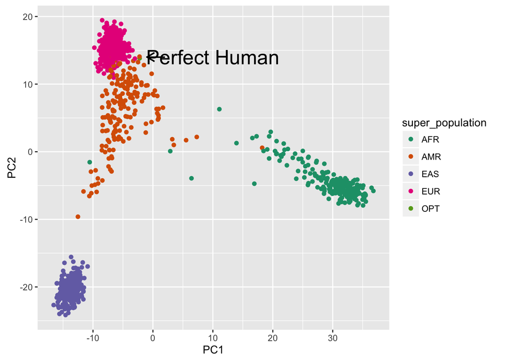

```r
embedded_samples %>%
  ggplot(aes(x=PC1, y=PC2, color=super_population)) +
    geom_point() +
    scale_color_brewer(palette="Dark2") +
    annotate("text", x=10, y=14, label="Perfect Human", size=7) +
    geom_segment(x=2,y=14,xend=-1,yend=14,arrow=arrow(length=unit(0.3, "cm")),color="black")
```

Which from PC3 you can see it is indeed hypothetical

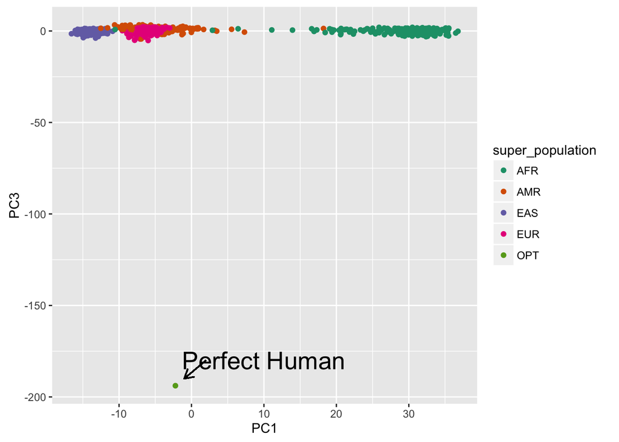

```r
embedded_samples %>%
  ggplot(aes(x=PC1, y=PC3, color=super_population)) +
  geom_point() +
  scale_color_brewer(palette="Dark2") +
  annotate("text", x=10, y=-180, label="Perfect Human", size=7) +
  geom_segment(x=2,y=-180,xend=-1,yend=-190,arrow=arrow(length=unit(0.3, "cm")),color="black")
```

Now, things got interesting when he reported that the nearest individual in the *embedded* dataset to this perfect human was a Puerto Rican woman:

```r
# get the two-dimensional embedding of fake subject
perfect_sample <- as.numeric(select(embedded_samples[1,], PC1, PC2))

# calculate the distance between fake subject and real subjects in
# the 2 dimensional space using Euclidean distance
dist <- embedded_samples %>%
  select(PC1, PC2) %>%
  as.matrix() %>%
  # these next few lines compute Euclidean distance using
  # piped operators
  sweep(., MARGIN=2, STATS=perfect_sample, FUN="-") %>%
  magrittr::raise_to_power(2) %>%
  rowSums() %>%
  sqrt()

# now find the nearest real subject
o <- order(dist)

sample_name <- embedded_samples$sample_name[o[2]]
sprintf("[%s](https://catalog.coriell.org/0/sections/Search/Sample_Detail.aspx?Ref=%s&PgId=166)", sample_name, sample_name)
```

[1] “[HG00737](https://catalog.coriell.org/0/sections/Search/Sample_Detail.aspx?Ref=HG00737&PgId=166)”

The over-interpretation of PCA strikes:

[Medical Daily](http://www.medicaldaily.com/biologist-says-puerto-rican-women-possess-ideal-genotype-perfect-human-dna-ancestry-313956)  
[HuffPost](http://www.huffingtonpost.com/julio-pabon/the-closet-perfect-human-_b_6304366.html)  
[El Nuevo Dia (Puerto Rican Newspaper)](http://www.elnuevodia.com/ciencia/ciencia/nota/serhumanoperfectoseriapuertorriqueno-1903858/) [Google Translate](https://translate.google.com/translate?sl=es&tl=en&js=y&prev=_t&hl=en&ie=UTF-8&u=http%3A%2F%2Fwww.elnuevodia.com%2Fciencia%2Fciencia%2Fnota%2Fserhumanoperfectoseriapuertorriqueno-1903858%2F&edit-text=&act=url)  
[Latin Times](http://www.latintimes.com/new-study-reveals-perfect-human-genetically-speaking-caribbean-island-280363)  
[The Backlash…](http://globalvoicesonline.org/2014/12/17/the-perfect-human-doesnt-live-in-puerto-rico-or-any-other-country/)

[*and a lot more*](https://www.google.com/?gws_rd=ssl#q=perfect+human+pachter)

In fact, Dr. Pachter published this analysis precisely due to the common over-interpretation of simple data analyses like these. This exercise was a great example of how easily over-interpretation of data analysis (PCA in this case), and our simplistic models of very complex systems (the genotype-phenotype relationship) can lead to conclusions that without thoughtful and ethical thinking can be easily over-hyped.

### Summary

Principal Component Analysis is a conceptually simple but powerful EDA tool. It is very useful at many stages of analyses. Its interpretation can be very ad-hoc, however. It is part of large set of unsupervised methods based on *matrix decompositions*